# Lösungen dichotomer logistischer Regression

Dieser Beitrag wurde zuerst auf https://borisls.github.io/ veröffentlicht.

Die logistische Regression wird als ein Klassifikationsverfahren verwendet. Hierbei wird versucht ein Zusammenhang zwischen den (in diesem Beispiel drei) erklärenden Variablen (*features* `f0`, `f1` und `f2`) und der dichotomen abhängigen Variable `y.class` zu modellieren. *Dichotom* bedeutet dabei, dass die abhängige Variable nur zwei Ausprägungen haben kann z.B. ein Unternehmen ist solvent oder insolvent oder eine E-Mail ist Spam oder kein Spam. Die logistische Regression ermittelt hierbei keine direkte Einschätzung, sondern besitzt als Ergebnis die Eintrittswahrscheinlichkeit eines Ereignisse in Abhängigkeit der erklärenden Variablen.

In diesem Beitrag wird das grundlegende Vorgehen für die Lösung eines logistischen Regressionsmodell in **R** dargestellt. Dies erfolgt zum einen als Step-by-Step-Lösung durch die Anwendung der *batch gradient descent-method* und die `optim`-Funktion. Dieses Vorgehen ist grundsätzlich schon schon aus dem [Beitrag](https://borisls.github.io/blog/regression.html) über die multivariate (linearen) Regression bekannt und wird für die logistische Regression modifiziert. Zum anderen wird die in **R** vorhandene Funktion `glm` verwendet.

```r
library(ggplot2)
library(dplyr)
library(tidyr)
```

### Diagnostic Functions

Bevor das Vorgehen für die logistische Regression dargestellt wird, werden noch zwei ergänzenden Funktionen definiert, die für die Darstellung des Klassifizierungsproblems und die Analyse des geschätzten logistischen Regressionsmodells hilfreich sind.

Die Funktion `plot.classification` stellt das Klassifizierungsproblem grafisch dar. Hierfür wird der Zusammenhang zwischen den *features* `f1` und `f2` in einem Scatterplot dargestellt. Die zwei unterschiedlichen Gruppen der abhängigen Variable `y` unterscheiden sich hierbei durch die Farbe.

```r
plot.classification <- function(f1, f2, y, title.plot){

  data.plot <- data.frame(f1 = f1,
                          f2 = f2,
                          col = as.factor(y))
  g <- ggplot(data.plot, aes(x=f1, y=f2, color=col)) +
              geom_point(size = 2) +
              labs(title=title.plot)

  return(g)

}
```

Die Funktion `confusion.matrix` ermittelt diese Wahrheitsmatrix für die beiden Ergebnisvektoren `actual.class` (die tatsächliche Klasse) und ``predicted.class` (die prognostizierte Klasse).

```r
confusion.matrix <- function(actual.class, predicted.class){

  df <- data.frame(Actual = actual.class,
                   Predicted = predicted.class)

  dd <- df %>% group_by(Actual, Predicted) %>%
               summarize(Anzahl = n()) %>%
               complete(Actual,
                        Predicted=actual.class) %>%
               ungroup() %>%
               mutate(Actual = paste("Actual", Actual, sep = "_Class_"),
                      Predicted = paste("Predicted", Predicted, sep = "_Class_"))

  act.clas <- unique(dd$Actual)
  pre.clas <- unique(dd$Predicted)

  r <- as.data.frame(matrix(NA, nrow=length(act.clas), ncol=length(pre.clas)))
  rownames(r) <- act.clas
  colnames(r) <- pre.clas

  cl <- act.clas[1]

  for(cl in act.clas){

    new.row <- dd %>% filter(Actual == cl) %>%
                      spread(Predicted, Anzahl, fill=0.0) %>%
                      select(-Actual)

    r[cl, ] <- new.row

  }

  return(r)
}
```

### Darstellung des Klassifizierungsproblems

Im ersten Schritt wird ein Klassifizierungsproblem erstellt. Hierfür werden der *features* `f0`, `f1` und `f2` in der Designmatrix `design.mx` erzeugt. Anschließend wird die Variable `y` als Linearkombination dieser drei *features* erzeugt. Die Zielvariable `y.class` des Klassifzierungsproblems wird aus `y` abgeleitet. Die größten 20% der Variable `y` werden einer Klasse zugeordnet. Die weiteren 80% bilden die zweite Klasse. Entsprechend stellt `y.class` die dichotome abhängigen Variable dar. Die grafische Darstellung des Klassifizierungsproblems erfolgt mit der Funktion `plot.classification`.

```r
set.seed(15102016)
m <- 10000

design.mx <- as.matrix(cbind(
                              rep(1, m),
                              runif(m, -1, 1), runif(m, -1, 1)))

colnames(design.mx) <- c("f0", "f1", "f2")
y = design.mx %*% c(3,-2,7)
y.class <- ifelse(y > quantile(y, 0.8), 1, 0)
```

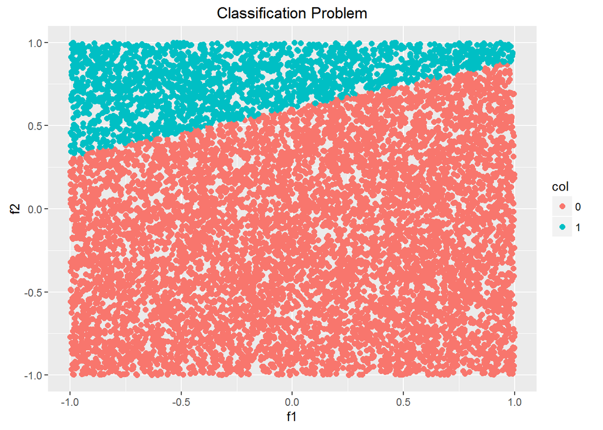

### Step-by-Step-Lösung der logistischen Regression

In diesem Teil wird das Vorgehen für die Lösung der [linearen Regression](https://borisls.github.io/blog/regression.html) für die logistische Regression adaptiert. Hierfür wird zuerst die Hilfsfunktion `sigmoid` benötigt. Die Funktion stellt den Link zwischen den Beobachtungen und der erklärenden Variable dar. Für Details zu der logistischen Regression sei an dieser Stelle auf die vielfältige Literatur zu diesem Thema verwiesen.

```r
sigmoid <- function(X, theta){

  z <- X %*% theta
  r <- 1 / (1 + exp(-z))
  return(r)
}
```

Für die numerische Lösung der logistischen Regression wird wieder eine Kostenfunktion `cost` benötigt, die minimiert werden soll. Die Minimierung erfolgt einmal über das *batch gradient descent*-Verfahren und zum anderen über die Optimierungsfunktion `optim`.

```r
cost <- function(par, X, y, lambda = 0){

  m <- length(y)
  h <- sigmoid(X, par)

  regTerm <- lambda/(2*m) * (sum(par^2) - par[1]^2)

  J <- 1/m * sum((-y * log(h)) - ((1 - y) * log(1 - h))) + regTerm
  return(J)
}
```

#### Batch Gradient Descent

Das *batch gradient descent*-Verfahren ist bereits aus der multivariaten linearen Regression bekannt. Nach Anpassung der Ermittlung des Parameters `h = sigmoid(X, theta)` muss der Algorithmus in seiner Struktur nicht weiter angepasst werden.

```r
descent.gradient <- function(X, y, theta.dg, alpha, n.iter, lambda){

  m <- length(y)
  J.hist <- rep(0, n.iter)
  t.hist <- matrix(0, nrow=n.iter+1, ncol=length(theta.dg))
  t.hist[1,] <- theta.dg

  regIndex <- rep(1, length(theta.dg))
  regIndex[1] <- 0

  for(i in 1:n.iter){

    h <- sigmoid(X, theta = theta.dg)

    regTerm <-  lambda/m * theta.dg * regIndex

    theta.dg = theta.dg - alpha * ( (1/m) * (t(X) %*% (h-y)) + regTerm)

    J.hist[i] <- cost(X, y, par=theta.dg, lambda)
    t.hist[i+1,] <- theta.dg
  }

  Cost.hist <- data.frame(Iteration = seq(1:n.iter),
                       Cost = J.hist)

  Theta.hist <- as.data.frame(t.hist)
  colnames(Theta.hist) <- paste0("f", seq(0,length(theta.dg)-1))
  Theta.hist$Iteration <- seq(0, n.iter, 1)

  return(list(theta = theta.dg,
              Cost.hist = Cost.hist,
              Theta.hist = Theta.hist))
}

theta.initial <- c(0,0,0)

dg.result <- descent.gradient(X=design.mx, y=y.class, theta.dg=theta.initial, alpha=0.03, n.iter=10000, lambda = 0)
dg.result$theta
```

```
##         [,1]
## f0 -4.295880
## f1 -2.025269
## f2  7.087519
```

Der Verlauf der Kostenfunktion ist in der nachfolgenden Abbildung dargestellt. Es ist ersichtlich, dass die Kostenfunktion konvergiert.

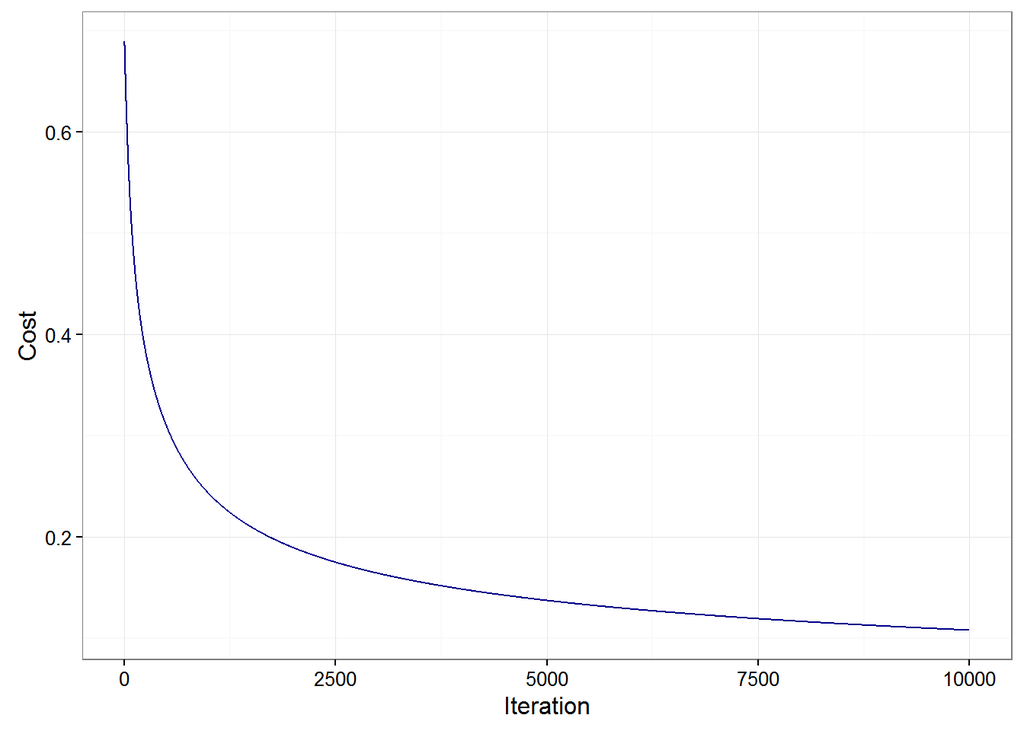

Die dichotome logistische Regression liefert als Ergebnis keine direkte Klassenzuweisung, sondern einen Wert im Intervall 0 bis 1. Dieser Wert lässt sich als Wahrscheinlichkeit interpretieren. Er besagt, wie hoch die Wahrscheinlichkeit für das Vorliegen der Klasse 1 ist. Standardmäßig wird ab einem Schwellwert von 0,5 die Beobachtung der Klasse 1 zugeordnet. Der Vektor `y.pred.dg` enthält somit die prognostizierten Klassen.

```r
y.pred.dg <- ifelse(sigmoid(X = design.mx, theta = dg.result$theta) > 0.5,
                    1, 0)
```

Die Modellgüte lässt sich mit den beiden Funktionen `plot.classification` und `confusion.matrix` darstellen.

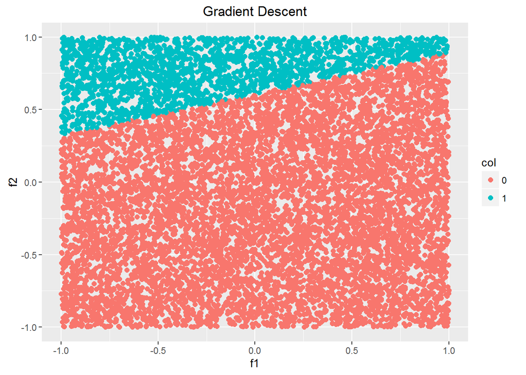

```
##                Predicted_Class_0 Predicted_Class_1
## Actual_Class_0              8000                 0
## Actual_Class_1                16              1984
```

#### Optim-Function in R

Für die Lösung des Optimierungsproblems lässt sich auch die in **R** vorhanden `optim`-Funktion verwenden. Die explizite Formulierung der Funktion `descent.gradient` ist somit nicht mehr notwendig. In der `optim`-Funktion ist anzugeben, welche Funktion `fn` (hier `cost`) zu minierem ist und welche Parameter (`par`) hierzu verändert werden sollen. Das Ergebnis der Optimierung wird in `theta.optim` vorgehalten und mit diesen Parameter eine Klassenzuweisung `y.pred.opt` ermittelt.

```r
theta_optim <- optim(par=theta.initial,
                          fn=cost,
                          X = design.mx,
                          y = y.class,
                          lambda = 0)

theta.optim <- theta_optim$par

y.pred.opt <- ifelse(sigmoid(X = design.mx, theta = theta.optim) > 0.5,
                       1, 0)
```

Die Modellgüte lässt sich wieder mit den beiden Funktionen `plot.classification` und `confusion.matrix` darstellen.

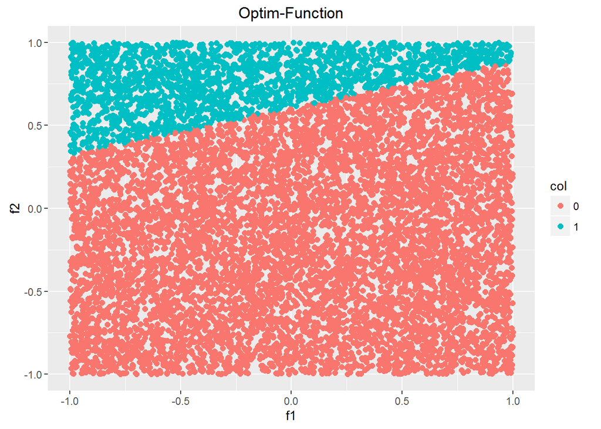

```
##                Predicted_Class_0 Predicted_Class_1
## Actual_Class_0              7995                 5
## Actual_Class_1                 8              1992
```

### Anwendung der Funktion `glm` zur Lösung der logistischen Regression

Das Standardvorgehen für die Lösung der logistischen Regression in **R** ist die Funktion `glm` (*generalized linear model*). Eine Beschreibung der Funktion findet sich z.B. [hier](http://data.princeton.edu/R/glms.html) und [hier](http://nlp.stanford.edu/manning/courses/ling289/logistic.pdf). Die Klassenzuweisung erfolgt in der Ergebnisvariable `y.pred.glm`.

```r
data.glm <- data.frame( f1 = design.mx[,2],
                        f2 = design.mx[,3],
                        y.class = y.class)

fit.full <- glm(y.class ~ f1 + f2,
                            data=data.glm, family=binomial())
y.pred.glm <- ifelse(sigmoid(X = design.mx, theta = as.vector(fit.full$coefficients)) > 0.5,
                       1, 0)
```

Die Modellgüte lässt sich wieder mit den beiden Funktionen `plot.classification` und `confusion.matrix` darstellen.

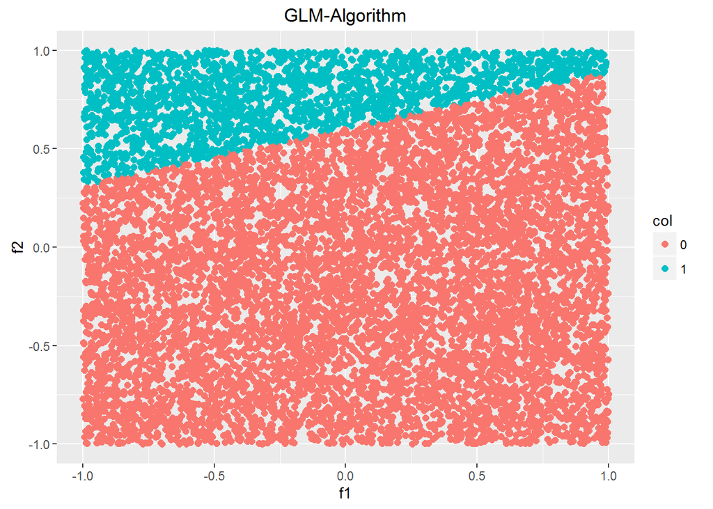

```
##                Predicted_Class_0 Predicted_Class_1
## Actual_Class_0              8000                 0
## Actual_Class_1                 0              2000
```